# Logistic regression

Lecture 19

2024-06-11

## Announcements

- Please be going through all prepare materials. The class is based on the understanding that you are consuming these materials.

## Predict interest rate…

from credit utilization and homeownership

```r
rate_util_home_fit <- linear_reg() |>
  fit(interest_rate ~ credit_util + homeownership, data = loans)
```

```r
tidy(rate_util_home_fit)
```

```
# A tibble: 4 × 5
  term                  estimate std.error statistic   p.value
  <chr>                    <dbl>     <dbl>     <dbl>     <dbl>
1 (Intercept)              9.93      0.140    70.8   0
2 credit_util              5.34      0.207    25.7   2.20e-141
3 homeownershipMortgage    0.696     0.121     5.76  8.71e-  9
4 homeownershipOwn         0.128     0.155     0.827 4.08e-  1
```

## Intercept

```
# A tibble: 4 × 5
  term                  estimate std.error statistic   p.value
  <chr>                    <dbl>     <dbl>     <dbl>     <dbl>
1 (Intercept)              9.93      0.140    70.8   0
2 credit_util              5.34      0.207    25.7   2.20e-141
3 homeownershipMortgage    0.696     0.121     5.76  8.71e-  9
4 homeownershipOwn         0.128     0.155     0.827 4.08e-  1
```

- Intercept: Loan applicants who rent and have 0 credit utilization are predicted to receive an interest rate of 9.93%, on average.

## Slopes

```
# A tibble: 4 × 5
  term                  estimate std.error statistic   p.value
  <chr>                    <dbl>     <dbl>     <dbl>     <dbl>
1 (Intercept)              9.93      0.140    70.8   0
2 credit_util              5.34      0.207    25.7   2.20e-141
3 homeownershipMortgage    0.696     0.121     5.76  8.71e-  9
4 homeownershipOwn         0.128     0.155     0.827 4.08e-  1
```

- All else held constant, for each additional percent credit utilization is higher, interest rate is predicted to be higher, on average, by 0.0534%.
- All else held constant, the model predicts that loan applicants who have a mortgage for their home receive 0.696% higher interest rate than those who rent their home, on average.
- All else held constant, the model predicts that loan applicants who own their home receive 0.128% higher interest rate than those who rent their home, on average.

# Transformations

## Predict log(interest rate)

```r
rate_log_cc_fit <- linear_reg() |>
  fit(log(interest_rate) ~ credit_checks, data = loans)

tidy(rate_log_cc_fit)
```

```
# A tibble: 2 × 5
  term          estimate std.error statistic  p.value
  <chr>            <dbl>     <dbl>     <dbl>    <dbl>
1 (Intercept)     2.39     0.00512     468.  0
2 credit_checks   0.0236   0.00166      14.2 2.39e-45
```

## Model

```
# A tibble: 2 × 5
  term          estimate std.error statistic  p.value
  <chr>            <dbl>     <dbl>     <dbl>    <dbl>
1 (Intercept)     2.39     0.00512     468.  0
2 credit_checks   0.0236   0.00166      14.2 2.39e-45
```

$$\widehat{log(interest~rate)} = 2.39 + 0.0236 \times credit~checks$$

## Slope

```
# A tibble: 2 × 5
  term          estimate std.error statistic  p.value
  <chr>            <dbl>     <dbl>     <dbl>    <dbl>
1 (Intercept)     2.39     0.00512     468.  0
2 credit_checks   0.0236   0.00166      14.2 2.39e-45
```

For each additional credit check, log of interest rate is predicted to be higher, on average, by 0.0236%.

## Interpreting the coefficient on credit check

All else constant, what is the effect of a **1 additional** credit check.

$$\widehat{log(interest~rate)} = 2.39 + 0.0236 \times (credit~checks + 1)$$

$$\widehat{log(interest~rate)} = 2.39 + 0.0236 \times credit~checks +\mathbf{0.0236\times 1}$$

$$\widehat{interest~rate} = e^{2.39 }e^{ 0.0236 \times credit~checks}e^{ \mathbf{0.0236\times 1}}$$

$$e^{ \mathbf{0.0236\times 1}} = 1.024$$

For each additional credit check, interest rate is predicted to be higher, on average, by **a factor of 1.024**.

# Logistic regression

## What is logistic regression?

- Similar to linear regression…. but
- Modeling tool when our response is categorical

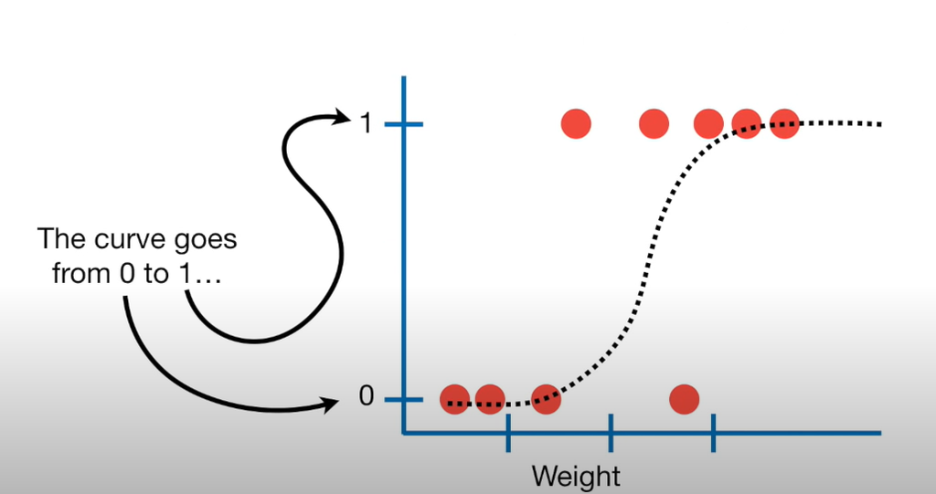

## Modelling binary outcomes

- Variables with binary outcomes follow the **Bernouilli distribution**:
  - $y_i \sim Bern(p)$
  - $p$: Probability of success
  - $1-p$: Probability of failure
- We can’t model $y$ directly, so instead we model $p$

## Linear model

$$p_i = \beta_o + \beta_1 \times X_1 + \cdots + \epsilon$$

- But remember that $p$ must be between 0 and 1
- We need a **link function** that transforms the linear model to have an appropriate range

## Logit link function

The **logit** function take values between 0 and 1 (probabilities) and maps them to values in the range negative infinity to positive infinity:

$$logit(p) = log \bigg( \frac{p}{1 - p} \bigg)$$

## This isn’t exactly what we need though…..

- Recall, the goal is to take values between -$\infty$ and $\infty$ and map them to probabilities.
- We need the opposite of the link function… or the *inverse*
- Taking the inverse of the logit function will map arbitrary real values back to the range [0, 1]

## Generalized linear model

- We model the logit (log-odds) of $p$ :

$$logit(p) = log \bigg( \frac{p}{1 - p} \bigg) = \beta_o + \beta_1 \times X1_i + \cdots + \epsilon$$

- Then take the inverse to obtain the predicted $p$:

$$p_i = \frac{e^{\beta_o + \beta_1 \times X1_i + \cdots + \epsilon}}{1 + e^{\beta_o + \beta_1 \times X1_i + \cdots + \epsilon}}$$

## A logistic model visualized

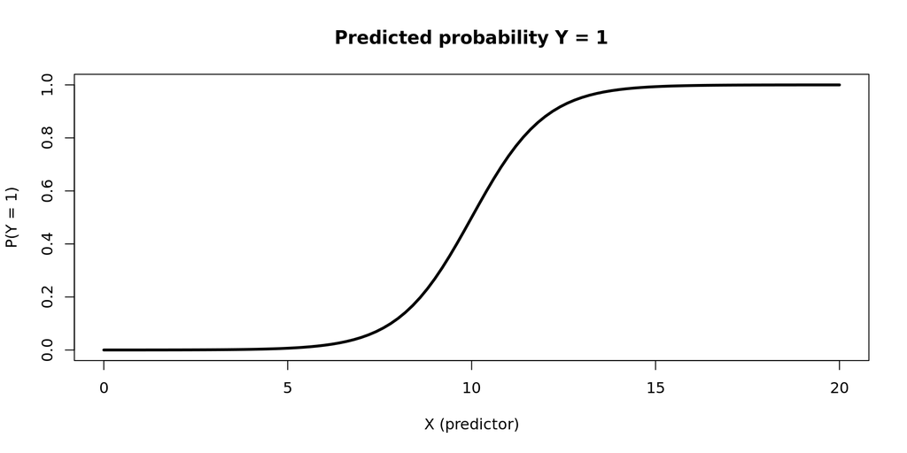

## Takeaways

- Generalized linear models allow us to fit models to predict non-continuous outcomes
- Predicting binary outcomes requires modeling the log-odds of success, where p = probability of success

[🔗 sta199-summer24.github.io](https://sta199-s24.github.io/) · [❓ Ask on Ed](https://edstem.org/us/courses/59071/discussion/)